# Part II - (FordGoBike Dataset)

## by (Victoria Nyaguthii)

## Investigation Overview

> In this investigation,i wanted to see the frequency behaviour of the bike riders and the bike ids.My main focus is the bike id which coverred the most time,most used and the age distribution based on the member genders.

## Dataset Overview

> The forgo Bike dataset presents historical data on a set of people who have rented out bikes,and detailed information such as their station of start and end point,their age,the duration taken and the memebrship type.Some records on 'member_birth_year' and 'member_gender' have been dropped due to missing data

## (Visualization 1) -Bikes vs Duration in seconds

> I wanted to investigate the time taken (duration in secs) distribution compared to the number of bike trips made in the dataset

```
Text(0,0.5,'Number of Bike Hire')
```

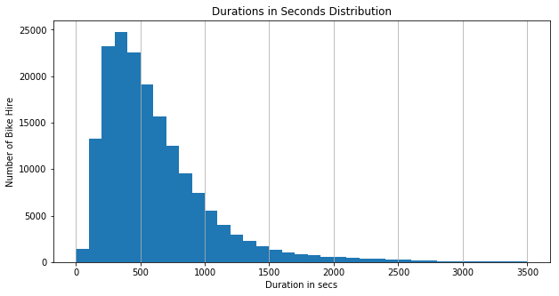

## (Visualization 2) -member age vs Number of Bike Hire

> I wanted to investigate the Age distribution based on the number of bike hires.This would help in giving a clear vision on the age gropu of most of the users in the dataset

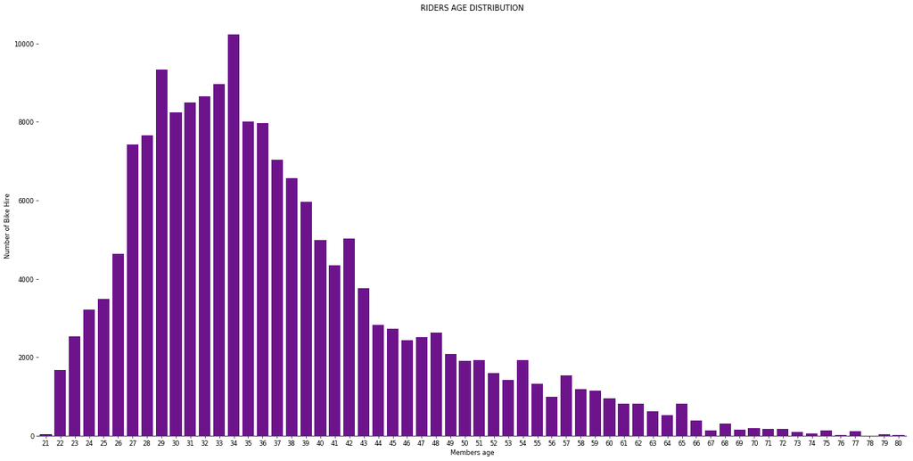

## (Visualization 3)Member birth year vs Member Gender

> I wanted to find out the distribution of the member gender in regards to to their age

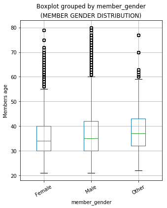

## (Visualization 3) Top used Bikes

> I wanted to investigate the top most used bikes in the dataset.

[figure not shown]

## (Visualization 4) Some numerical Correlation

> I wanted to do some numerical visualizations .This is to help in understanding correlations of the variables in the dataset.

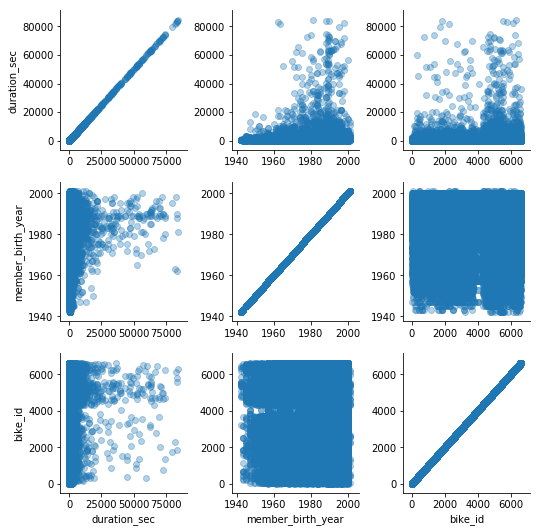